# Bias introduced by over/underdispersion - report 2

Michal Burdukiewicz

17.10.2015

ouPoisson - over- and underdispersed Poisson

# Over- and underdispersion of Poisson distribution

The Poisson distribution is typically use to model count data, as FOCI data. Although theoretically valid, this approach my fail for many real-life data sets, where some non-zero counts are nevertheless treated as zeroes leading to the underestimation of real variance. On the contrary, some object with zero counts might be omitted by the counting software, which leads to the partially or completely zero-truncated data. In this case we longer observe Poisson distribution and have to model the the data using alternative distributions (as negative binomial distribution) or quasi-likelihood (as Quasi-Poisson distribution).

# ouPoisson distribution

This section is the same as in the first report.

$P\{X = K\} = \begin{cases} (1 - p) + p \exp^{-\lambda},\text{if } k = 0\\ p \frac{\lambda^k \exp^{-\lambda}}{k!},\text{if } k = 1, 2, \ldots \end{cases}$ as in Wang et al. (2012).

$p$ - parameter of over- or underdispersion. If $p = 1$, than we have normal Poisson distribution. When $p < 1$, the distribution is overdispersed. In this case $p$ may be see as a fraction of non-zero cases that are converted to 0.

When $p > 1$, the distribution is underdispersed under condition that: $p \leq \frac{1}{1 - \exp{(- \lambda)}}$

Mean: $\mu = p \lambda$

Variance: $\sigma^2 = p \lambda + p(1 - p)\lambda^2$

# Impact on mean value

Since $\mu = p \lambda$, we expect linear change (as seen on the plot below).

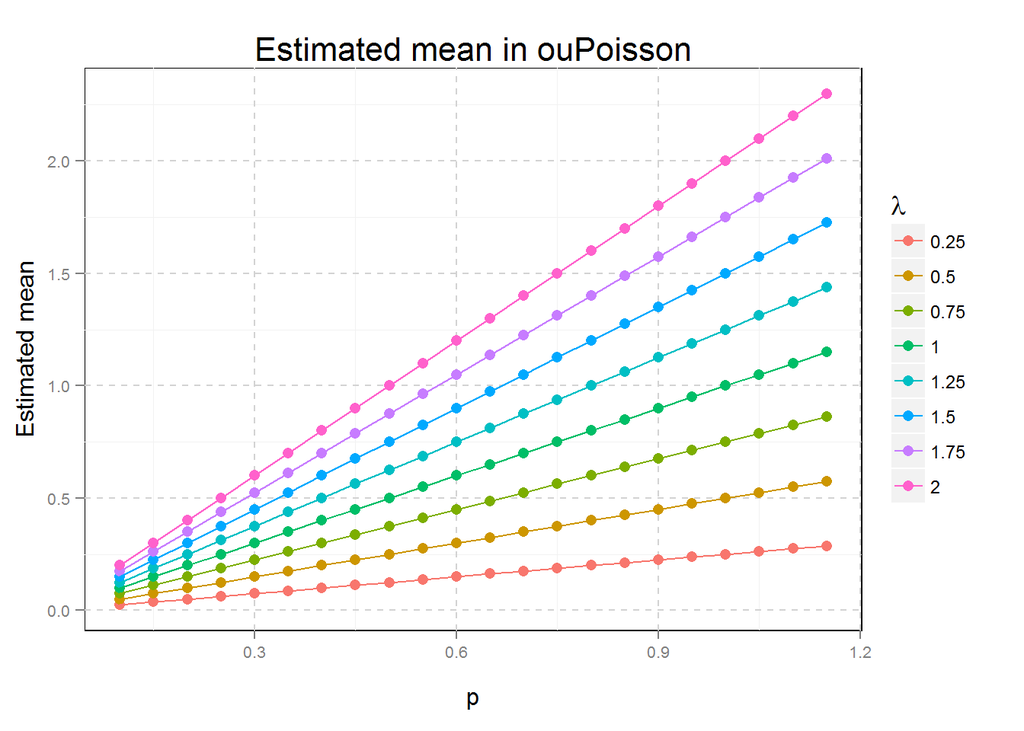

We define bias as:

$Bias[\mu] = E[\mu] - \mu = p \lambda - \lambda = \lambda (p - 1)$

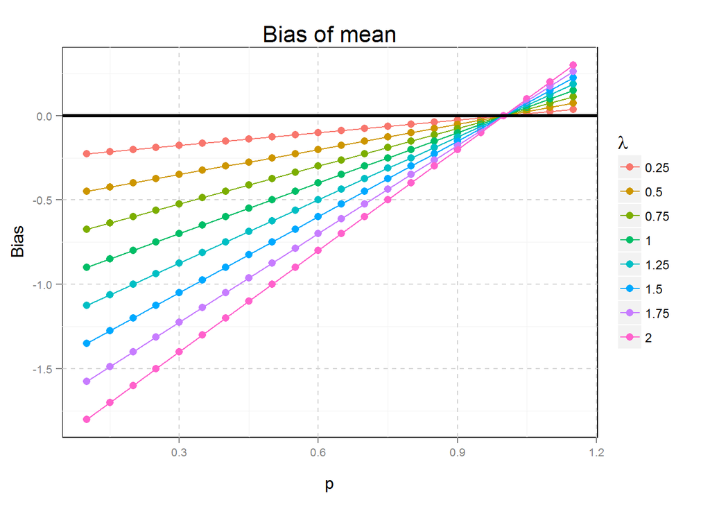

The bias increases along with values of $\lambda$ and $p$. For overdispersion, we underestimate the real value of $\lambda$. The situation is the opposite for underdispersion.

# Impact on variance

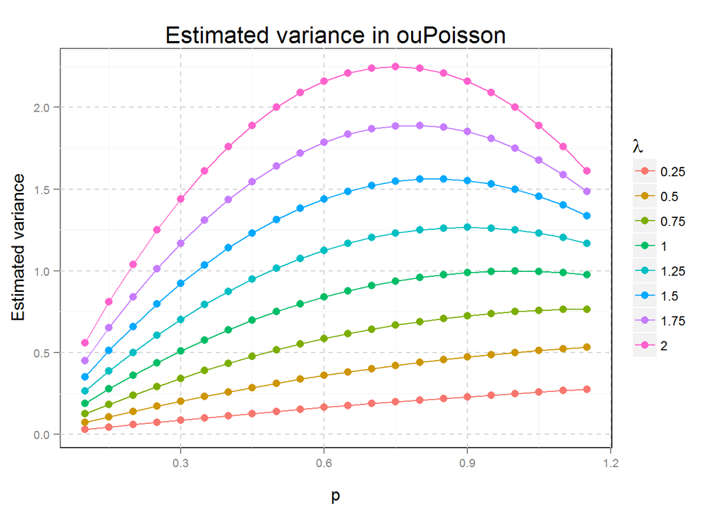

$Bias[\sigma^2] = E[\sigma^2] - \sigma^2 = p \lambda + p(1 - p)\lambda^2 - \lambda = \lambda^2 p (1 - p) + \lambda(p - 1)$

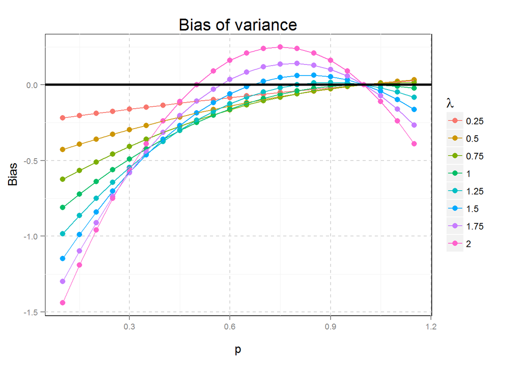

References

Wang, Hongyue, Changyong Feng, Xinming Tu, and Jeanne Kowalski. 2012. “A Comparison of Two Test Statistics for Poisson Overdispersion/Underdispersion.” *Applied Mathematics* 03 (07): 795–99. doi:10.4236/am.2012.37118.